# Impacto dos Gastos Públicos Federais

JOAO VITOR DA SILVA SANTOS

2024-12-06

## Evolução da participação do Estado na Economia

### Revolução Industrial e o Liberalismo Econômico (Século XVIII - XIX)

**Características:** Ideias de Adam Smith e outros economistas liberais promovem mercados autorregulados, com mínima intervenção estatal.  
**Consequências:**  
- O Estado atua apenas em funções básicas, como segurança, infraestrutura, e aplicação da lei.  
- Políticas de “laissez-faire” predominam, especialmente na Inglaterra.

### Crises e o Avanço do Socialismo (Século XIX)

**Características:** Crescimento das desigualdades e movimentos trabalhistas pressionam por maior intervenção estatal.  
**Exemplos:**  
- Primeiras legislações trabalhistas.  
- Surgimento das ideias socialistas, propondo o controle estatal sobre os meios de produção.

### Primeira Guerra Mundial e o Fortalecimento do Estado (1914-1918)

**Características:** Durante a guerra, os governos assumem maior controle sobre as economias para financiar e sustentar o esforço militar.  
**Exemplos:**  
- Nacionalizações de indústrias estratégicas.  
- Racionamento e controle de preços.

### A Grande Depressão e o Keynesianismo (1929-1940)

**Características:** A crise de 1929 mostrou os limites do liberalismo clássico, levando à aceitação de que o Estado deveria intervir na economia.  
**Exemplo marcante:**  
- O “New Deal” de Franklin D. Roosevelt nos Estados Unidos, com investimentos públicos em larga escala para reativar a economia.  
**Contribuição teórica:**  
- John Maynard Keynes, em *The General Theory of Employment, Interest and Money* (1936), propôs que o governo deveria regular a demanda agregada.

### Segunda Guerra Mundial e o Planejamento Estatal (1939-1945)

**Características:** O Estado consolida seu papel como organizador econômico.  
**Exemplos:**  
- Controle estatal de recursos para sustentar o esforço de guerra.  
- Planejamento econômico de longo prazo em economias de guerra.

### Pós-Guerra e a Ascensão do Desenvolvimentismo (Década de 1940 - 1960)

**Características:** Especialmente em países da América Latina, Ásia e Europa devastada pela guerra, o governo assume papel central no desenvolvimento econômico.  
**Marcos principais:**  
- Teoria da industrialização por substituição de importações, defendida por economistas como Raúl Prebisch.  
- Criação de instituições internacionais, como o FMI e o Banco Mundial, para apoiar o planejamento e a reconstrução econômica.

## Revisão de Contabilidade Nacional

A contabilidade nacional trabalha com as identidades: Produto Nacional, Renda Nacional e Dispêndio Nacional.
$$PN \equiv RN \equiv DN$$

A produção agregada da economia pode ser representada por uma função de produção:
$$PN = Y = f(K, L)$$
As identidades Renda e Dispêndio representam a demanda agregada:
$$DN = DA = C + I + G + NX$$

$$RN = DA = C + I + G + NX$$

Em equilíbrio, a oferta agregada é igual à demanda agregada:
$$OA = DA$$
Logo:
$$Y = C + I + G + NX$$
E:
$$G = Y - C - I - NX$$

[figure not shown]

### O Agente

O governo é um agente que **equilibra o fluxo de renda**, promovendo justiça social, estimulando a atividade econômica, regulando mercados e estabilizando a economia. Ele é essencial para evitar desequilíbrios e garantir o funcionamento sustentável da economia, especialmente em situações de crises ou desigualdades estruturais.

## Impacto dos gastos públicos pelo modelo IS - LM

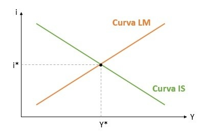

## Impactos Positivos

### Estímulo à Demanda Agregada

- Gastos em infraestrutura, educação e saúde podem aumentar a demanda agregada, impulsionando a produção e o emprego.
- Em momentos de recessão, esses gastos ajudam a reativar a economia, funcionando como uma ferramenta de estímulo fiscal.

Função Renda
$$Y = C + S$$

Função Consumo
$$C = Y - S$$

Então:
$$\frac{\Delta C}{\Delta Y} = 1$$

Temos a **propensão marginal a consumir**. Em termos percentuais, um aumento marginal na renda de 1% eleva o nível de consumo dos indivíduos:
$$\frac{\Delta \% C}{\Delta \% Y}$$

### Investimentos em Infraestrutura

- Melhorias em transporte, energia e comunicações aumentam a eficiência produtiva e a competitividade do setor privado.

### Redução de Desigualdades

- Gastos sociais, como transferências de renda e programas de combate à pobreza, ajudam a reduzir desigualdades e melhorar o bem-estar da população.

### Estabilização Econômica

- O governo pode utilizar os gastos para mitigar flutuações econômicas, suavizando períodos de recessão ou boom.

> Apesar de fazer um discurso otimista sobre a situação econômica do Brasil em meio à crise financeira global, o presidente brasileiro disse à população que “não tenha medo de consumir com responsabilidade”.

> “Se você está com dívidas, procure antes equilibrar seu orçamento. Mas se tem um dinheirinho no bolso ou recebeu o décimo terceiro, e está querendo comprar uma geladeira, um fogão ou trocar de carro, não frustre seu sonho, com medo do futuro”, afirmou Lula.

> E o presidente acrescentou: “Se você não comprar, o comércio não vende. E se a loja não vender, não fará novas ecomendas à fábrica. E aí a fábrica produzirá menos e, a médio prazo, o seu emprego poderá estar em risco.”

> Lula encorajou ainda os empresários a continuarem investindo, e recomendou que o setor financeiro estimule o crédito e baixe os juros, que ele ainda considera “muito altos”.

> Para o presidente, “nossa maior defesa hoje é a força do mercado interno”.

## Efeito Bolsa Família

Um estudo do Banco Mundial, intitulado *“Cash Transfers and Formal Labour Markets – Evidence from Brazil”*, desmente a ideia de que o Bolsa Família desestimula o trabalho. A pesquisa aponta que o programa, além de combater a pobreza e a desigualdade, tem efeitos positivos na economia local e no mercado de trabalho formal, especialmente após sua expansão em 2009.

### Principais Pontos:

- **Efeito multiplicador:** Cada dólar investido gera **2,16 dólares** na economia local.
- **Impacto no mercado de trabalho:** A expansão do programa resultou em aumento do consumo, mais empregos formais (principalmente no setor privado, com remuneração de até dois salários mínimos) e maior arrecadação tributária.
- **Inclusão no mercado de trabalho:** A maioria dos novos empregos foi ocupada por pessoas que **nunca foram beneficiárias do programa**.
- **Consumo formal:** Dois terços do consumo adicional ocorreram em **estabelecimentos formais**.

### Conclusão:

O estudo conclui que programas de transferência de renda, como o Bolsa Família, não apenas reduzem a pobreza, mas também impulsionam economias locais e mercados de trabalho formais.

## Impactos Negativos

### Aumento do Déficit Público

- Se os gastos excederem a arrecadação por longos períodos, podem gerar um déficit público elevado, aumentando a dívida pública e os custos com juros.

[figure not shown]

Um aumento expressivo de 285,79%

### Inflação

- Gastos excessivos em uma economia já aquecida podem gerar pressão inflacionária, reduzindo o poder de compra.

### Efeito Crowding-Out

- O financiamento de gastos por meio de emissão de títulos pode elevar as taxas de juros, desestimulando o investimento privado.

[figure not shown]

Detentores da dívida pública

### Ineficiência e Corrupção

- Mal uso de recursos públicos, seja por projetos ineficazes ou práticas ilícitas, pode reduzir o retorno econômico e social dos gastos.

### Dependência de Programas Sociais

- Políticas mal planejadas podem criar dependência em relação a programas de assistência, reduzindo incentivos para o trabalho e a produtividade.